# Univariate Plots Section

#### pH, Quality and Citric Acid Brackets.

This plot has pH vs quality and the points are colored by citric acid brackets. As we can see, there are more darker colored dots at the upper left of the plot which means that higher quality wines tend to have higher citric acid and lower pH.

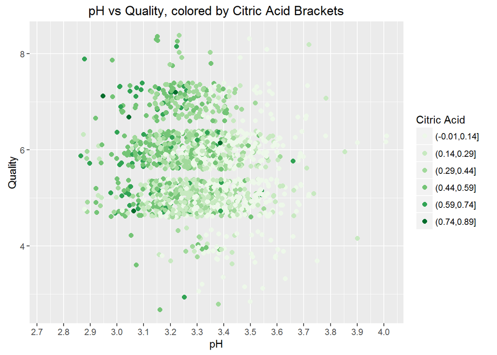

[output not shown]

# Multivariate Analysis

#### Talk about some of the relationships you observed in this part of the investigation. Were there features that strengthened each other in terms of looking at your feature(s) of interest?

For a lot of cases, citric acid when considered with other variables gives stronger indication for higher quality wines. We can see that the combinations of citric acid and fixed acidity, volatile acidity and pH really strengthen each other in accordance to our interest of quality values.

#### Were there any interesting or surprising interactions between features?

I think it is interesting that there are a lot of wines which have citric acid amount equals to zero but still it seems to be an important feature in the analysis.

#### OPTIONAL: Did you create any models with your dataset? Discuss the strengths and limitations of your model.

# Final Plots and Summary

#### Plot One

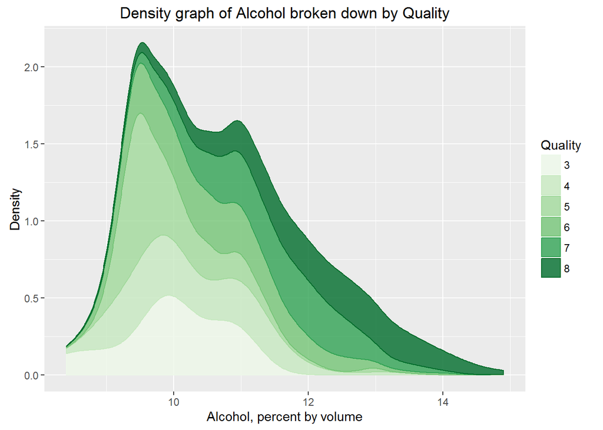

#### Description One

This plot shows the density of alcohol percentage by volume and stacked by quality factors. The reason why I chose it was becasue from the chart, we can see cleary the positive correlation between alchol and quality. Most of the higher quality wines are distributed towards higher alcohol direction.

#### Plot Two

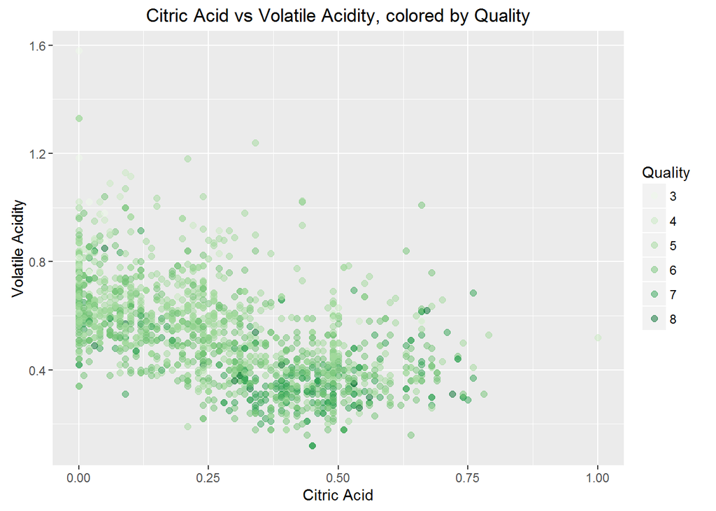

#### Description Two

I think this plot is good in showing the relationship between Volatile Acidity, Citric Acid and Quality. We can see that wines with higher citric acid and lower volatile acidity received better quality scores.

#### Plot Three

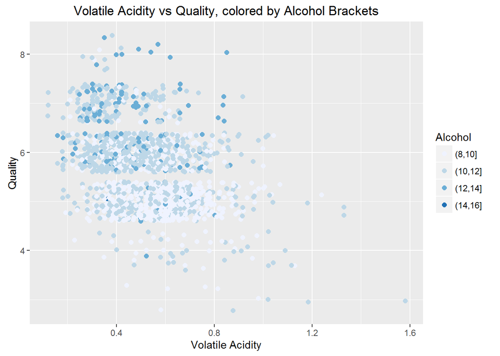

#### Description Three

# Reflection

This project is really helpful for students who are learning to practice exploratory data analysis. R is a very powerful tool to assist us with our tasks of univariate, bivariate and multivariate plotting and analysys. In bivariate analysys, we found the correlations between pairs of variables in the dataset. However, there might be interactions between more than two variables, that’s why multivariate analysis was needed in the project.

I learnt that choosing the right colors in the plots really helps with the process. I used the default palette initially but was advised to use a sequential palette from RColorBrewer which was really useful in identifying trends and relationships. I used GGpairs for getting the overall idea on relationships between variables. After the first project review, I was advised to use GGCorr which really made it easier for me to visualize the correlations.

There are other combinations of variables that haven’t been investigated in this study such as residual and density or chlorides and sulphates (both have medium correlation). Besides, different types of charts on the same variables can also reveal interesting relationships that we haven’t found. Future approaches can study this dataset from those different angles. And since some variables seem to have linear correlation with quality, we can apply a regression model to build a machine learning model for wine quality prediction.